# hospital_distance

This project was inspired by a reddit post where a user posted a beautiful plot about voting behaviour. (his code can be found here https://gist.github.com/blu3r4y/f47fbad0deda5a9f0eb13aaec8dd42a5) In the thread somebody asked which program was used to make it (python) and somebody remarked that it should be possible in R too. I never worked with the google maps api before, so I thought I’ll do it.

To be honest I first only took a quick look at the plot and thought it should be done in a few minutes. I was wrong, but I learned cool stuff.

```r
library(tidyverse)
library(XML)
library(bitops)
library(RCurl)
library(stringr)
library(ggrepel)
library(scales)
```

The data can be found here: https://www.verwaltung.steiermark.at/cms/dokumente/12228622_118256397/c174dcf0/vorl%C3%A4ufiges%20Befragungsergebnis_mitProzent.pdf (althouth we will work with an already formatted .csv - thanks to the above mentioned reddit user)

The issue is a new “Leitspital” (lead-hospital in clumsy english) in Stainach-Pürgg, which should replace three smaller ones in the surrounding country. So for some people a new hospital is build near them, but for others the new hospital would be farther away than an old one. The people were asked for a vote (pro/contra) about building it. The question then was, is the proportion of yes-votes per city associated to change in distance to the next available hospital?

```r
spital <- read_csv("./leitspital.csv")

hospital_new <- "Stainach-Pürgg"
hospital_old <- spital %>%        # there are 3 hospitals in Bad Aussee, Rottenmann and Schladming, respectively.
  filter(num_hospitals > 0) %>%
  select(municipality)

key = "YOUR_KEY_HERE"
```

Now, I searched the internet for similar projects and found a function on stackoverflow, which I only needed to change minimally for my needs. (https://stackoverflow.com/questions/16863018/getting-driving-distance-between-two-points-lat-lon-using-r-and-google-map-ap)

So I used this function to call google for driving duration between two places, mostly origin to the new hospital. The second one is using the first one to call for driving duration to the old three hospitals and returning the shortest one.

```r
drive_duration <- function(origin,destination = hospital_new){
  origin <- paste0(str_replace_all(origin," ",""),",Styria,Austria")
  destination <- paste0(str_replace_all(destination," ",""),",Styria,Austria")
  xml.url <- paste0('https://maps.googleapis.com/maps/api/distancematrix/xml?origins=',origin,'&destinations=',destination,'&mode=driving&sensor=false&key=',key)
  xmlfile <- xmlParse(getURL(xml.url))
  dur <- xmlValue(xmlChildren(xpathApply(xmlfile,"//duration")[[1]])$value)
  duration <- as.numeric(dur)/60
  return(duration)
}




duration_to_closest_hospital <- function(origin){
  durations <- vector(mode = "numeric", length = nrow(hospital_old))
  for (i in 1:nrow(hospital_old)) {
    durations[i] <- drive_duration(origin, hospital_old[i,1])
  }
  return(min(durations))
}
```

From here on it is straight forward. The analysis has already been done by somebody else, I only wanted to learn to replicate it. So I calculated the driving durations for the new hospital and the nearest old one, took the difference and then plotted them against voting percentage.

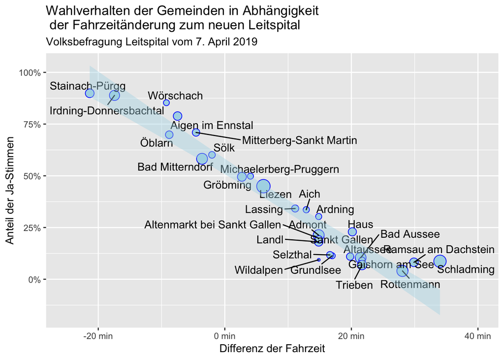

```r
spital$duration_new_hosp <- do.call(rbind, lapply(spital$municipality, drive_duration))
spital$duration_old_hosp <- do.call(rbind, lapply(spital$municipality, duration_to_closest_hospital))

spital <- spital %>%
  mutate(duration_diff = duration_new_hosp - duration_old_hosp,
         percent_yes = (yes/valid))


text_formatter <- function(x){
  paste(x,"min")
}

hospital_distances <- ggplot(data = spital, aes(x = duration_diff, y = percent_yes))+
  geom_point(aes(size = population), fill = "lightblue", colour = "blue", shape = 21, show.legend = F)+
  geom_text_repel(aes(label = municipality)) +
  geom_smooth(method = "lm", linetype = 0, fill = "lightblue") +
  xlab("Differenz der Fahrzeit") +
  ylab("Anteil der Ja-Stimmen") +
  scale_x_continuous(limits = c(-25,40), labels = text_formatter) +
  scale_y_continuous(labels = percent) +
  ggtitle("Wahlverhalten der Gemeinden in Abhängigkeit \n der Fahrzeitänderung zum neuen Leitspital",
          subtitle = "Volksbefragung Leitspital vom 7. April 2019")

hospital_distances
```